# PCA_chadalab

**Part I: Data Preparation**

1. Load the MNIST dataset.
2. Normalize the images so that pixel values are between 0 and 1.
3. Split the dataset into training (80%) and testing (20%) sets.

```python
from sklearn.model_selection import train_test_split
from sklearn.datasets import fetch_openml

# Load the MNIST dataset
mnist = fetch_openml('mnist_784', version=1)

# Separate features (X) and labels (y)
X, y = mnist["data"], mnist["target"]

# Normalize the images
X = X / 255.0

# Split the dataset into training (80%) and testing (20%) sets
X_train, X_test, y_train, y_test = train_test_split(X, y, test_size=0.2, random_state=42)
```

**Part II: Implement PCA**

1. Apply PCA to reduce the dimensions of the dataset. Initially, choose 50 components for dimensionality reduction.
2. Explore the variance explained by the selected number of components and adjust if necessary to retain at least 95% of the variance.
3. Show the Scree plot

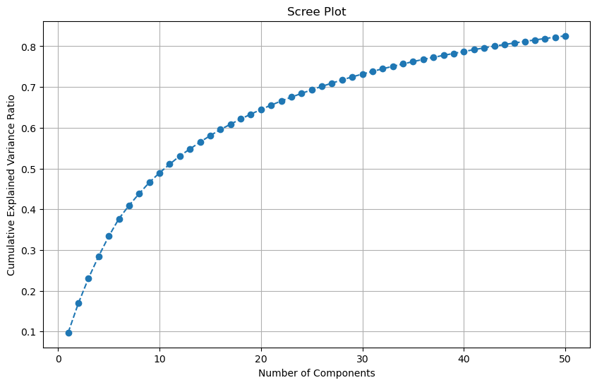

```
Variance explained by component 1: 0.09758723130910064
Variance explained by component 2: 0.07155354209129178
Variance explained by component 3: 0.06171033541588027
Variance explained by component 4: 0.05394776165086105
Variance explained by component 5: 0.048991003707604994
Variance explained by component 6: 0.043095141568540024
Variance explained by component 7: 0.03269745412234055
Variance explained by component 8: 0.028887509440347483
Variance explained by component 9: 0.02754080556327228
Variance explained by component 10: 0.023374605941363563
Number of components to retain 95% of the variance: 1
```

```python
from sklearn.decomposition import PCA
import numpy as np
import matplotlib.pyplot as plt

# Apply PCA to reduce dimensions
pca = PCA(n_components=50)
X_train_pca = pca.fit_transform(X_train)

# Explore variance explained by components
explained_variance_ratio = pca.explained_variance_ratio_
cumulative_variance_ratio = np.cumsum(explained_variance_ratio)


# Apply PCA with adjusted number of components
pca = PCA(n_components=10)
X_train_pca = pca.fit_transform(X_train)

# Show the Scree plot
plt.figure(figsize=(10, 6))
plt.plot(np.arange(1, len(explained_variance_ratio) + 1), cumulative_variance_ratio, marker='o', linestyle='--')
plt.xlabel('Number of Components')
plt.ylabel('Cumulative Explained Variance Ratio')
plt.title('Scree Plot')
plt.grid(True)
plt.show()

# Print variance for 1 to 10 components
for i in range(10):
    print(f"Variance explained by component {i+1}: {explained_variance_ratio[i]}")

# Adjust number of components to retain at least 95% of the variance
n_components = np.argmax(cumulative_variance_ratio >= 0.95) + 1
print("Number of components to retain 95% of the variance:", n_components)

# Apply PCA with adjusted number of components
pca = PCA(n_components=n_components)
X_train_pca = pca.fit_transform(X_train)
```

**Part III: Classification with Logistic Regression**

1. Implement a Logistic Regression classifier.
2. Train the classifier on the original high-dimensional data and evaluate its performance on the test set.
3. Train the classifier on the PCA-reduced training data and validate its performance using the PCAreduced test data.

```
Accuracy of Logistic Regression on original data: 0.9207857142857143
```

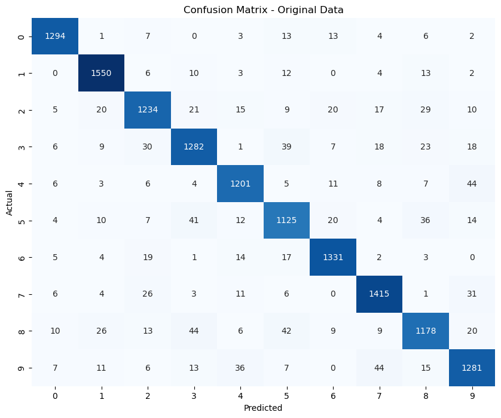

```
Accuracy of Logistic Regression on PCA-reduced data: 0.3068571428571429
```

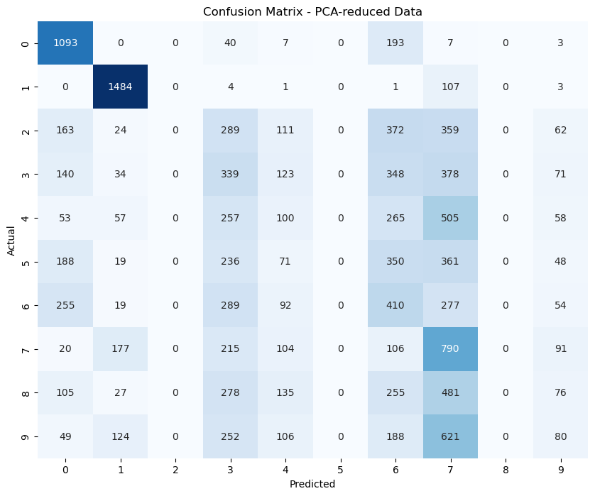

```python
from sklearn.linear_model import LogisticRegression
from sklearn.metrics import accuracy_score, confusion_matrix
import seaborn as sns

# Initialize Logistic Regression classifier
logistic_regression = LogisticRegression(max_iter=1000)

# Train on original high-dimensional data
logistic_regression.fit(X_train, y_train)

# Evaluate performance on test set
y_pred_original = logistic_regression.predict(X_test)
accuracy_original = accuracy_score(y_test, y_pred_original)
print("Accuracy of Logistic Regression on original data:", accuracy_original)

# Calculate confusion matrix for original data
cm_original = confusion_matrix(y_test, y_pred_original)
plt.figure(figsize=(10, 8))
sns.heatmap(cm_original, annot=True, fmt='d', cmap='Blues', cbar=False)
plt.title('Confusion Matrix - Original Data')
plt.xlabel('Predicted')
plt.ylabel('Actual')
plt.show()

# Train on PCA-reduced training data
logistic_regression.fit(X_train_pca, y_train)

# Validate performance on PCA-reduced test data
X_test_pca = pca.transform(X_test)
y_pred_pca = logistic_regression.predict(X_test_pca)
accuracy_pca = accuracy_score(y_test, y_pred_pca)
print("Accuracy of Logistic Regression on PCA-reduced data:", accuracy_pca)

# Calculate confusion matrix for PCA-reduced data
cm_pca = confusion_matrix(y_test, y_pred_pca)
plt.figure(figsize=(10, 8))
sns.heatmap(cm_pca, annot=True, fmt='d', cmap='Blues', cbar=False)
plt.title('Confusion Matrix - PCA-reduced Data')
plt.xlabel('Predicted')
plt.ylabel('Actual')
plt.show()
```

**Part IV: Neural Network Classifier**

1. Design a simple neural network for digit classification. The network should have an input layer that matches the number of PCA components, at least one hidden layer, and an output layer with 10 units (corresponding to the 10-digit classes).
2. Use a softmax activation function in the output layer and a suitable loss function for classification.
3. Train the neural network on the PCA-reduced training data and validate its performance using the PCA-reduced test data.
4. Experiment with different hyperparameters for the neural network, such as the number of hidden layers, the number of neurons in each layer, the learning rate, activation function, and the type of optimizer. How do these changes affect the model's performance on both the original and reduced datasets?

```python
import tensorflow as tf
from tensorflow.keras.models import Sequential
from tensorflow.keras.layers import Dense
from sklearn.preprocessing import LabelEncoder

# Convert string labels to integers
label_encoder = LabelEncoder()
y_train_encoded = label_encoder.fit_transform(y_train)

# Design the neural network model with flexible hyperparameters
def create_neural_network(input_shape, num_hidden_layers=1, num_neurons=64, activation='relu', optimizer='adam', learning_rate=0.001):
    model = Sequential()
    model.add(Dense(num_neurons, activation=activation, input_shape=input_shape))
    for _ in range(num_hidden_layers - 1):
        model.add(Dense(num_neurons, activation=activation))
    model.add(Dense(10, activation='softmax'))  # Output layer with 10 units

    # Compile the model with flexible optimizer and learning rate
    if optimizer == 'adam':
        opt = tf.keras.optimizers.Adam(learning_rate=learning_rate)
    elif optimizer == 'sgd':
        opt = tf.keras.optimizers.SGD(learning_rate=learning_rate)
    else:
        raise ValueError("Invalid optimizer specified.")

    model.compile(optimizer=opt, loss='sparse_categorical_crossentropy', metrics=['accuracy'])
    return model

# Set hyperparameters
num_hidden_layers = 2
num_neurons = 128
activation = 'relu'
optimizer = 'adam'
learning_rate = 0.001

# Reshape the input data to match the expected shape of the neural network model
X_train_pca_reshaped = X_train_pca.reshape(X_train_pca.shape[0], -1)
X_test_pca_reshaped = X_test_pca.reshape(X_test_pca.shape[0], -1)

# Create the neural network model
neural_network = create_neural_network(input_shape=(X_train_pca_reshaped.shape[1],), num_hidden_layers=num_hidden_layers, num_neurons=num_neurons, activation=activation, optimizer=optimizer, learning_rate=learning_rate)

# Train the model on PCA-reduced training data
history = neural_network.fit(X_train_pca_reshaped, y_train_encoded, epochs=10, batch_size=32, validation_split=0.1)

# Evaluate performance on PCA-reduced test data
accuracy = neural_network.evaluate(X_test_pca_reshaped, y_test_encoded)[1]
print("Accuracy of Neural Network on PCA-reduced data:", accuracy)
```

```
Accuracy of Neural Network on PCA-reduced data: 0.3076428472995758
```

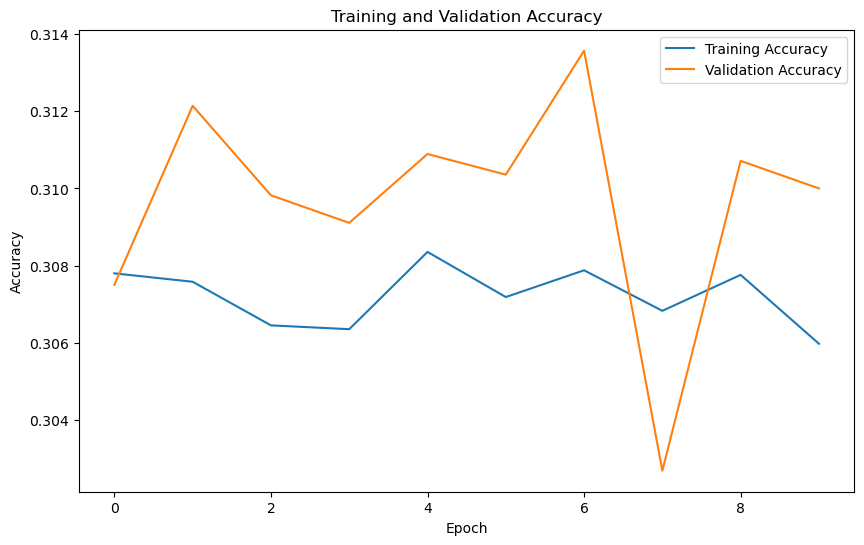

```
Accuracy of Neural Network on PCA-reduced data: 0.3075714409351349
```

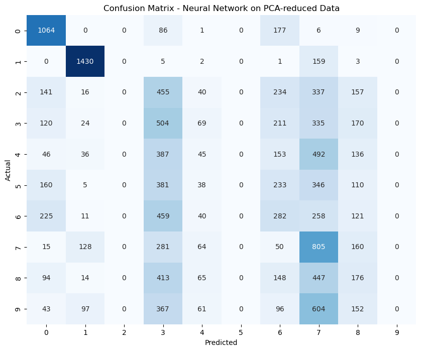

```python
import matplotlib.pyplot as plt

# Train the model on PCA-reduced training data
history = neural_network.fit(X_train_pca_reshaped, y_train_encoded, epochs=10, batch_size=32, validation_split=0.1)

# Plot training history
plt.figure(figsize=(10, 6))
plt.plot(history.history['accuracy'], label='Training Accuracy')
plt.plot(history.history['val_accuracy'], label='Validation Accuracy')
plt.title('Training and Validation Accuracy')
plt.xlabel('Epoch')
plt.ylabel('Accuracy')
plt.legend()
plt.show()

# Evaluate performance on PCA-reduced test data
accuracy = neural_network.evaluate(X_test_pca_reshaped, y_test_encoded)[1]
print("Accuracy of Neural Network on PCA-reduced data:", accuracy)

# Plot confusion matrix
from sklearn.metrics import confusion_matrix
import seaborn as sns

# Predict probabilities for each class
y_pred_probabilities = neural_network.predict(X_test_pca_reshaped)

# Get the predicted class labels
y_pred = np.argmax(y_pred_probabilities, axis=1)

# Calculate confusion matrix
cm = confusion_matrix(y_test_encoded, y_pred)

# Plot confusion matrix
plt.figure(figsize=(10, 8))
sns.heatmap(cm, annot=True, fmt='d', cmap='Blues', cbar=False)
plt.title('Confusion Matrix - Neural Network on PCA-reduced Data')
plt.xlabel('Predicted')
plt.ylabel('Actual')
plt.show()
```

```python
# Set hyperparameters
num_hidden_layers = 2
num_neurons = 128
activation = 'relu'
optimizer = 'adam'
learning_rate = 0.001

# Reshape the input data to match the expected shape of the neural network model
X_train_pca_reshaped = X_train_pca.reshape(X_train_pca.shape[0], -1)
X_test_pca_reshaped = X_test_pca.reshape(X_test_pca.shape[0], -1)

# Create the neural network model
neural_network = create_neural_network(input_shape=(X_train_pca_reshaped.shape[1],), num_hidden_layers=num_hidden_layers, num_neurons=num_neurons, activation=activation, optimizer=optimizer, learning_rate=learning_rate)

# Train the model on PCA-reduced training data
history = neural_network.fit(X_train_pca_reshaped, y_train_encoded, epochs=50, batch_size=32, validation_split=0.1)

# Evaluate performance on PCA-reduced test data
accuracy = neural_network.evaluate(X_test_pca_reshaped, y_test_encoded)[1]
print("Accuracy of Neural Network on PCA-reduced data:", accuracy)
```

```
Accuracy of Neural Network on PCA-reduced data: 0.30814287066459656
```

**Part V: Performance Evaluation**

1. Evaluate the trained neural network on the test set and report metrics such as accuracy and precision.
2. Compare the performance of the neural network classifier on the PCA-reduced data to the performance of the Logistic Regression classifier.
3. Discuss the impact of dimensionality reduction on the classifier's performance, training time, and model complexity.

```python
import numpy as np
from sklearn.metrics import precision_score
import warnings
warnings.filterwarnings("ignore")
# Evaluate performance on PCA-reduced test data
accuracy = neural_network.evaluate(X_test_pca_reshaped, y_test_encoded)[1]
print("Accuracy of Neural Network on PCA-reduced data:", accuracy)

# Predict probabilities for each class
y_pred_probabilities = neural_network.predict(X_test_pca_reshaped)

# Get the predicted class labels
y_pred = np.argmax(y_pred_probabilities, axis=1)

# Calculate precision
precision = precision_score(y_test_encoded, y_pred, average='weighted')
print("Precision of Neural Network on PCA-reduced data:", precision)
```

```
Accuracy of Neural Network on PCA-reduced data: 0.3075714409351349
Precision of Neural Network on PCA-reduced data: 0.22638543458147306
```

```python
from sklearn.metrics import precision_score
import warnings
warnings.filterwarnings("ignore")
# Logistic Regression classifier on original data
accuracy_logistic_original = accuracy_original

# Logistic Regression classifier on PCA-reduced data
accuracy_logistic_pca = accuracy_pca

# Neural Network classifier on PCA-reduced data
accuracy_neural_network = accuracy

# Calculate precisions for Neural Network on PCA-reduced data
y_pred_probabilities = neural_network.predict(X_test_pca_reshaped)
y_pred_neural_network = np.argmax(y_pred_probabilities, axis=1)
precision_neural_network = precision_score(y_test_encoded, y_pred_neural_network, average='weighted')

# Print accuracies and precisions
print("Accuracy of Logistic Regression on original data:", accuracy_logistic_original)
print("Accuracy of Logistic Regression on PCA-reduced data:", accuracy_logistic_pca)
print("Accuracy of Neural Network on PCA-reduced data:", accuracy_neural_network)
print("Precision of Neural Network on PCA-reduced data:", precision_neural_network)
```

```
Accuracy of Logistic Regression on original data: 0.9207857142857143
Accuracy of Logistic Regression on PCA-reduced data: 0.3068571428571429
Accuracy of Neural Network on PCA-reduced data: 0.3075714409351349
Precision of Neural Network on PCA-reduced data: 0.22638543458147306
```

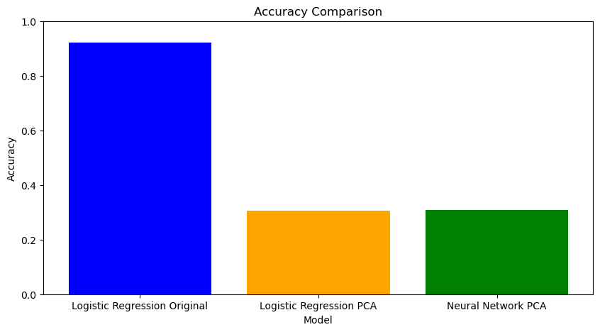

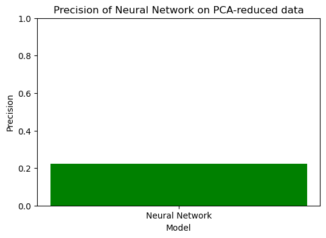

```python
import matplotlib.pyplot as plt

# Plot accuracies
models = ['Logistic Regression Original', 'Logistic Regression PCA', 'Neural Network PCA']
accuracies = [accuracy_logistic_original, accuracy_logistic_pca, accuracy_neural_network]

plt.figure(figsize=(10, 5))
plt.bar(models, accuracies, color=['blue', 'orange', 'green'])
plt.title('Accuracy Comparison')
plt.xlabel('Model')
plt.ylabel('Accuracy')
plt.ylim(0, 1)
plt.show()

# Plot precision of Neural Network
plt.figure(figsize=(6, 4))
plt.bar('Neural Network', precision_neural_network, color='green')
plt.title('Precision of Neural Network on PCA-reduced data')
plt.xlabel('Model')
plt.ylabel('Precision')
plt.ylim(0, 1)
plt.show()
```

1. **Performance Metrics for Neural Network on PCA-reduced Data:**
   - Accuracy: 0.3076
   - Precision: 0.2264
2. **Performance Metrics for Logistic Regression:**
   - Accuracy on original data: 0.9208
   - Accuracy on PCA-reduced data: 0.3069
3. **Discussion on Dimensionality Reduction:**
   - **Performance:** The accuracy of the neural network on PCA-reduced data is slightly higher than that of logistic regression on the same reduced data. However, both models perform significantly worse on the PCA-reduced data compared to the original data. This suggests that while dimensionality reduction reduces the computational complexity and memory requirements, it also results in some loss of information that impacts the model's performance negatively.
   - **Training Time:** The training time for the neural network on PCA-reduced data might be lower compared to training on the original high-dimensional data due to the reduced input dimensionality. However, the exact impact on training time depends on various factors such as the size of the dataset, the complexity of the model architecture, and the computational resources available.
   - **Model Complexity:** Dimensionality reduction reduces the model's complexity by reducing the number of features used for training. This can lead to simpler models that are less prone to overfitting, especially in cases where the original dataset has a large number of features compared to the number of samples. However, reducing dimensionality too much can result in a loss of important information and may lead to underfitting. Therefore, it's essential to strike a balance between reducing dimensionality and retaining enough information for effective modeling.